# Analysis of the Value-Weight Ratio of Commercial Landings in North Carolina Counties, 2014 - 2022

https://github.com/schirmaa7/Holsclaw-Kagiliery-Newton-Schirmacher_EDE_FinalProject_2025/tree/main

Ayden Schirmacher, Natalie Holsclaw, Tori Newton, and Julia Kagiliery

# 1 Rationale and Research Questions

Main Research Question: Is there a difference in the value-to-weight ratio from commercial landings in North Carolina between 2014-2022?

Sub-question A: Is there a difference in the value-to-weight ratio from commercial landings by SPECIES in North Carolina between 2014-2022?

Sub-question B: Is there a difference in the value-to-weight ratio from commercial landings by COUNTY in North Carolina between 2014-2022?

Null hypothesis for all questions: there is no difference in the value-to-weight ratio.

The dataset selected includes detailed records of commercial landings reported by species, county, and year across North Carolina from 2014 to 2022. This geographic and temporal scope allows for the exploration of both short-term fluctuations and longer-term trends. Having counties as the spatial unit captures regional differences and grouping by species helps in detecting differences between high-value species and lower-value, bulk-harvested species. By using value and weight as core variables, the study quantifies economic return per unit of harvest, providing insight into the changing efficiency and profitability of North Carolina’s commercial fishing industry.

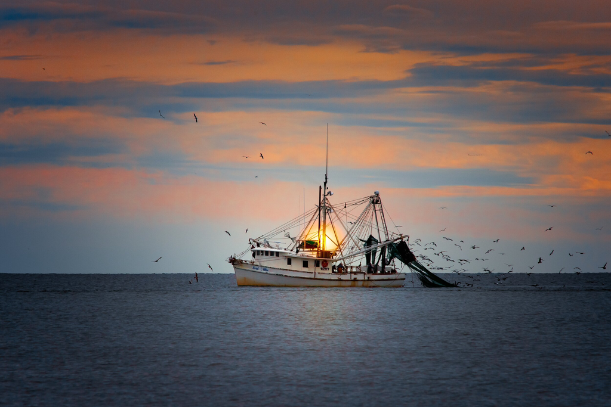

Shrimping Vessel in North Carolina

# 2 Dataset Information

The data used in this report come from commercial landings data collected by the North Carolina Department of Environmental Quality (NCDEQ). The North Carolina Division of Marine Fisheries collects data from commercial fishers via a ‘Trip Ticket Program’ where fishermen are required to report information related to their catch (1). Purchasers of seafood from commercial fishermen are required to collect this data in a form and submit it the N.C. Division of Marine Fisheries on a monthly basis. The goal of the program is to obtain accurate reports of commercial fishing so that fisheries managers can manage marine resources in a sustainable way. Data on commercial landings by county is also provided by the NCDEQ in their License and Statistic annual report and is used in this study as well.

The fisheries data from the NCDEQ dates back to 1972 and can be exported in .csv files by year with information on the species common name, weight, and landings value. For the purposes of this study, we utilized commercial landings data from 2014 to 2022. Because each year was downloaded as an individual .csv file, our first step in data wrangling was binding the data together. The data was cleaned to ensure it was in the proper format for analyses including corrections to the date format and removal of non-numeric characters from the landings value data. The data were filtered to only include species that had data across all years in the time period of this study. To compare larger groups of species, species were combined into sub-groups - i.e. crustaceans, mollusks, sharks and rays, etc. To get an idea of the true value of species groups, the value-to-weight ratio was calculated for each. The statistical analysis of this data was hindered by a non-normal distribution, but both linear and non-parametric tests were carried out in order to account for all possible methods of analyses.

Summary of Key Variables in Dataset

[output not shown]

# 3 Exploratory Analysis

*Analysis By Species Group*

A final analysis of the value-to-weight ratio by species group is shown in a year-by-year plot of the weight-to-value ratio (Figure 5). This shows the same information as Figures 3 and 4, but now differentiates by year. The x axis (weight) is log transformed in order to better visualize the differences between species groups – otherwise, the range of data is too small compared to crustaceans to be useful. Outlying values are labeled for every year. This plot confirms the outlying crustaceans, but also shows which years have certain species groups experiencing a ratio increase. An increasing ratio indicates that the value of the species landings has increased faster than the weight of the landings (where value-to-weight ratio is calculated by Value/Weight).

Overall, the exploratory plots for species groupings indicate that there is a high likelihood of the value-to-weight ratio of commercial landings in North Carolina being different between 2014 and 2022, and across species groups throughout that time period.

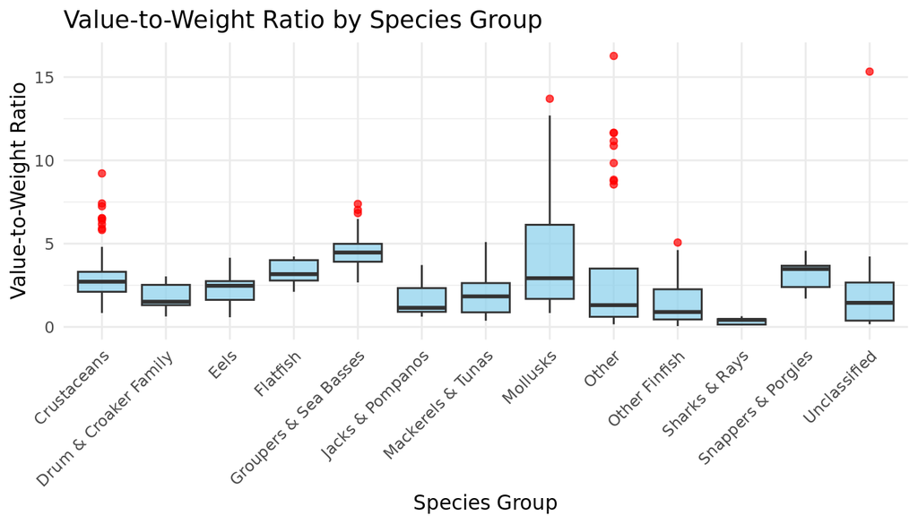

Figure 1. Average Weight-Value Ratio of Commercial Landings in North Carolina by Species Group, Averaged Over Time

```
## # A tibble: 117 × 5
## # Groups:   Year [9]
##    Year       species_group          Mean Median      SD
##    <date>     <chr>                 <dbl>  <dbl>   <dbl>
##  1 2014-01-01 Crustaceans            3.16  3.02   1.68
##  2 2014-01-01 Drum & Croaker Family  1.49  1.34   0.820
##  3 2014-01-01 Eels                   2.71  2.71  NA
##  4 2014-01-01 Flatfish               2.86  2.86   0.0474
##  5 2014-01-01 Groupers & Sea Basses  3.79  3.77   0.643
##  6 2014-01-01 Jacks & Pompanos       1.37  1.03   0.916
##  7 2014-01-01 Mackerels & Tunas      1.84  2.01   1.24
##  8 2014-01-01 Mollusks               3.42  2.09   2.81
##  9 2014-01-01 Other                  3.27  1.03   5.09
## 10 2014-01-01 Other Finfish          1.26  0.862  1.10
## # ℹ 107 more rows
```

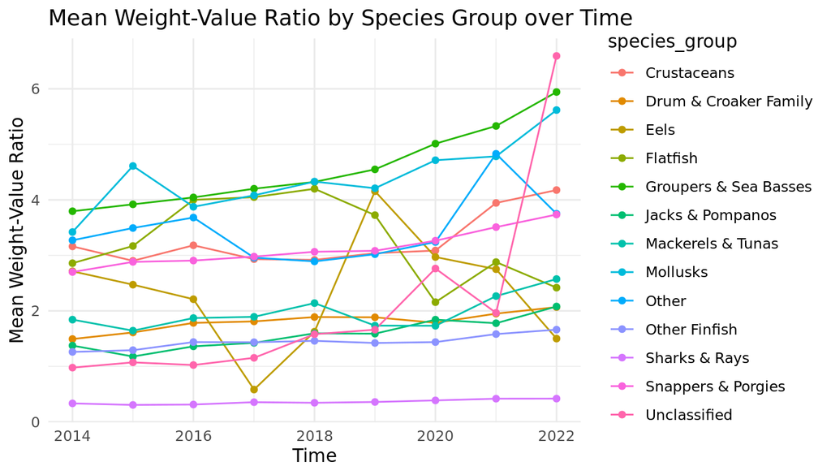

Figure 2. Average Weight-Value Ratio of Commercial Landings in North Carolina by Species Group, 2014-2022

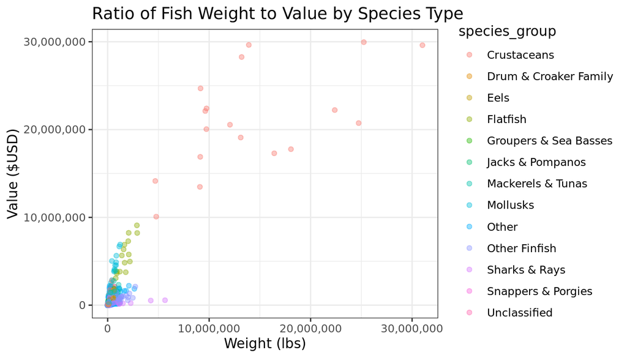

Figure 3. Value to Weight Ratio of Commercial Landings in North Carolina by Species Group, 2014-2022

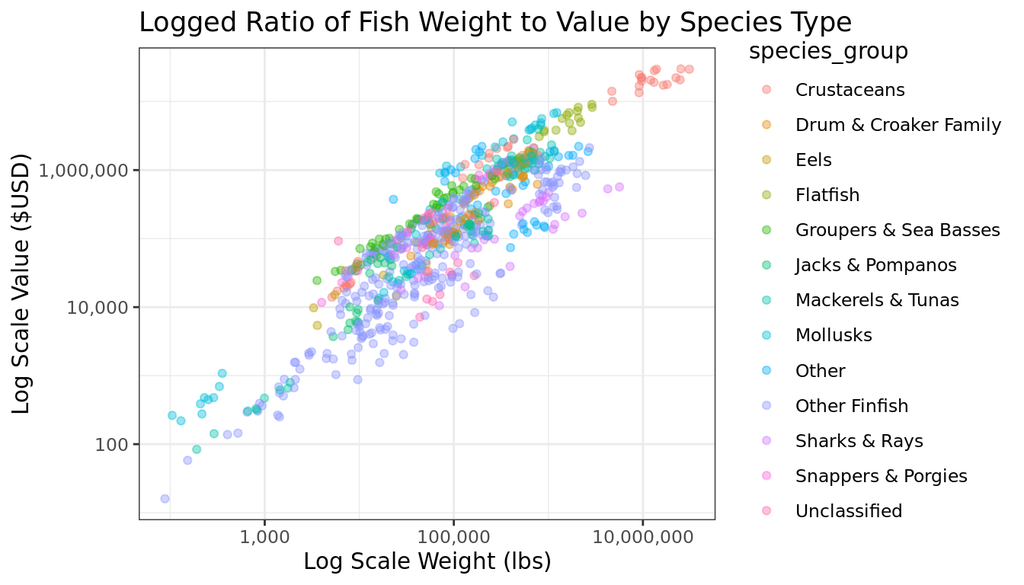

Figure 4. Log Transformed Value to Weight Ratio of Commercial Landings in North Carolina by Species Group, 2014-2022

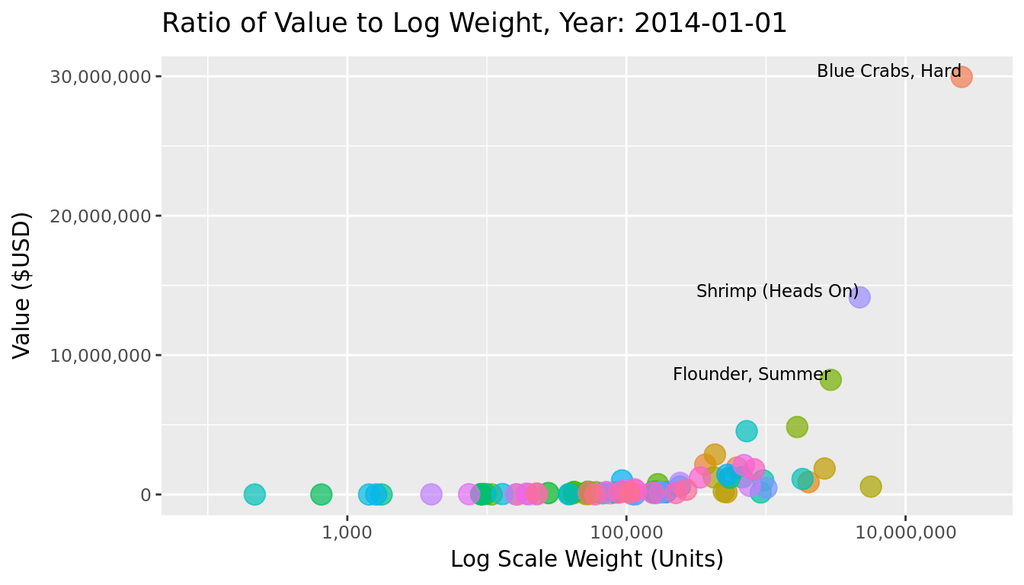

Figure 5. Annual Value to Log Weight Ratio of Commercial Landings in North Carolina by Species Group, 2014-2022, where annual outliers are labeled

Summary statistics grouped both by fish species and species type can be found below.

```
## # A tibble: 85 × 7
##    FISH       AverageWeight SDWeight AverageValue SDValue AverageValueWeightRa…¹
##    <chr>              <dbl>    <dbl>        <dbl>   <dbl>                  <dbl>
##  1 Amberjacks       157351.   38064.      180257.  5.28e4                  1.14
##  2 Anglerfis…        52310.   29738.       46494.  3.23e4                  0.829
##  3 Blue Crab…     19121690. 7214247.    21190145.  5.48e6                  1.18
##  4 Blue Crab…       501767.  170989.     1389211.  4.71e5                  2.79
##  5 Blue Crab…       262905.  109315.     1738248   6.30e5                  6.80
##  6 Bluefish        1174591.  382796.      666235.  1.77e5                  0.579
##  7 Bonito            12667.    4581.       19679.  7.15e3                  1.63
##  8 Butterfish        52178.   14808.       24453.  8.21e3                  0.465
##  9 Carp              21927.   14359.        2823.  2.00e3                  0.139
## 10 Catfishes       1296062.  587012.      367439   2.09e5                  0.278
## # ℹ 75 more rows
## # ℹ abbreviated name: ¹AverageValueWeightRatio
## # ℹ 1 more variable: SDRatio <dbl>
```

```
## # A tibble: 13 × 7
##    species_group         AverageWeight SDWeight AverageValue   SDValue
##    <chr>                         <dbl>    <dbl>        <dbl>     <dbl>
##  1 Crustaceans                5844310. 8305335.     9052404. 10563973.
##  2 Drum & Croaker Family       224488.  193975.      413979.   403072.
##  3 Eels                         24756.   22871.       56429.    60768.
##  4 Flatfish                   1520655.  771013.     4938050.  2472630.
##  5 Groupers & Sea Basses       106648.  150648.      390040.   439935.
##  6 Jacks & Pompanos             61371.   72458.       78474.    81030.
##  7 Mackerels & Tunas           371131.  298390.      863909.   778692.
##  8 Mollusks                    229424.  336874.     1450205.  2099176.
##  9 Other                       622703.  626818.      849817.   733474.
## 10 Other Finfish               213186.  422203.      216909.   365318.
## 11 Sharks & Rays               934671. 1284592.      214597.   171458.
## 12 Snappers & Porgies          107278.  112546.      366335.   422978.
## 13 Unclassified                 83775.   48933.      123028.    93178.
## # ℹ 2 more variables: AverageValueWeightRatio <dbl>, SDRatio <dbl>
```

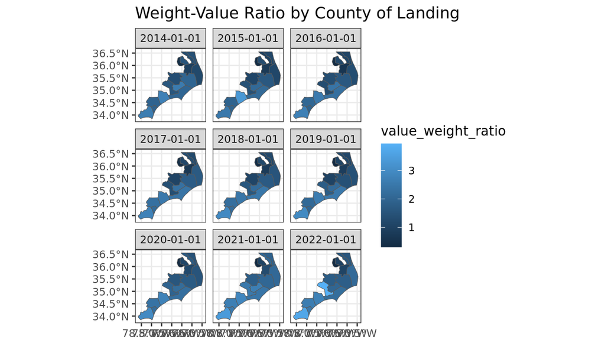

Figure 6. Value to Weight Ratio of Commercial Landings in North Carolina by County, 2014-2022

# 4 Analysis

Initially, data is checked for normality. Weight and value data is not normal, despite logarithm transformations, inverse transformations, and a box cox transformation. However, after utilizing a pearson correlation coefficient, we are able to note that there is a relationship between the weight and value of the commercial species.

```
## # A tibble: 12 × 2
##    species_group         pearson_correlation
##    <chr>                               <dbl>
##  1 Crustaceans                         0.893
##  2 Drum & Croaker Family               0.850
##  3 Flatfish                            0.899
##  4 Groupers & Sea Basses               0.980
##  5 Jacks & Pompanos                    0.976
##  6 Mackerels & Tunas                   0.818
##  7 Mollusks                            0.976
##  8 Other                               0.470
##  9 Other Finfish                       0.717
## 10 Sharks & Rays                       0.710
## 11 Snappers & Porgies                  0.989
## 12 Unclassified                        0.372
```

Using a multiple linear regression model, it can be determined that there are some significant differences in the value-to-weight ratios across species, holding all else constant and assuming that the impacts of the explanatory variable on the annual value-to-weight ratio apply for the study time period of 2014-2022. Although the value-to-weight ratio of this model is log transformed in an attempt to better satisfy the normality assumptions of multiple linear regression, it is known that there are still issues with normality. However, this can still be used to show generally what kinds of relationships exist between the various species.

The year is also a significant contributor to the value-to-weight ratio, with a p-value of ~0.007.

Given the R-squared value, the model explains ~33.44% of the variations in value-to-weight ratios. While this may seem low, the model is also statistically significant with a p-value less than 0.001. The assumptions of the model are not perfect and likely have issues with heteroscedasticity based on the Residuals plot. The residuals vs. fitted plot shows values clumped together but relatively evenly distributed above and below the line.

It can be concluded that there are significant differences in the value-to-weight ratio across species, holding all else constant. Therefore, we can reject the null hypothesis that there is no difference in the value-to-weight ratio between 2014-2022 across species. However, some issues may have disrupted these results. Issues include: potential heteroscedasticity of the data; there are also likely issues with spatial and temporal autocorrelation of the data.

```
##
## Call:
## lm(formula = log(value_weight_ratio) ~ species_group + Year,
##     data = species_clean)
##
## Residuals:
##      Min       1Q   Median       3Q      Max
## -2.85749 -0.49237  0.05865  0.50527  2.47763
##
## Coefficients:
##                                      Estimate Std. Error t value Pr(>|t|)
## (Intercept)                        -6.444e-01  6.233e-01  -1.034 0.301512
## species_groupDrum & Croaker Family -4.933e-01  1.865e-01  -2.645 0.008350 **
## species_groupEels                  -2.761e-01  3.231e-01  -0.854 0.393138
## species_groupFlatfish               1.542e-01  2.468e-01   0.625 0.532155
## species_groupGroupers & Sea Basses  4.850e-01  1.786e-01   2.716 0.006773 **
## species_groupJacks & Pompanos      -7.108e-01  2.154e-01  -3.300 0.001014 **
## species_groupMackerels & Tunas     -5.829e-01  1.681e-01  -3.467 0.000557 ***
## species_groupMollusks               1.412e-01  1.865e-01   0.757 0.449351
## species_groupOther                 -6.520e-01  1.978e-01  -3.295 0.001031 **
## species_groupOther Finfish         -1.110e+00  1.415e-01  -7.842 1.61e-14 ***
## species_groupSharks & Rays         -2.205e+00  2.154e-01 -10.236  < 2e-16 ***
## species_groupSnappers & Porgies     8.942e-02  2.154e-01   0.415 0.678150
## species_groupUnclassified          -8.914e-01  2.154e-01  -4.139 3.91e-05 ***
## Year                                9.414e-05  3.475e-05   2.709 0.006901 **
## ---
## Signif. codes:  0 '***' 0.001 '**' 0.01 '*' 0.05 '.' 0.1 ' ' 1
##
## Residual standard error: 0.8848 on 715 degrees of freedom
## Multiple R-squared:  0.3344, Adjusted R-squared:  0.3223
## F-statistic: 27.63 on 13 and 715 DF,  p-value: < 2.2e-16
```

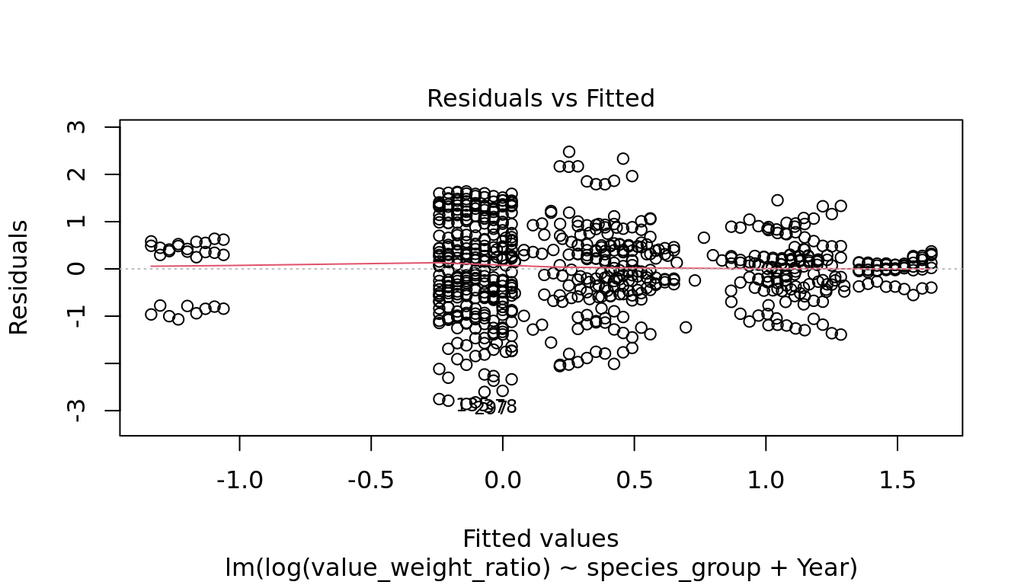

Model 1. Multiple Linear Regression of Logged Value to Weight Ratio of Commercial Landings in North Carolina by Species, 2014-2022

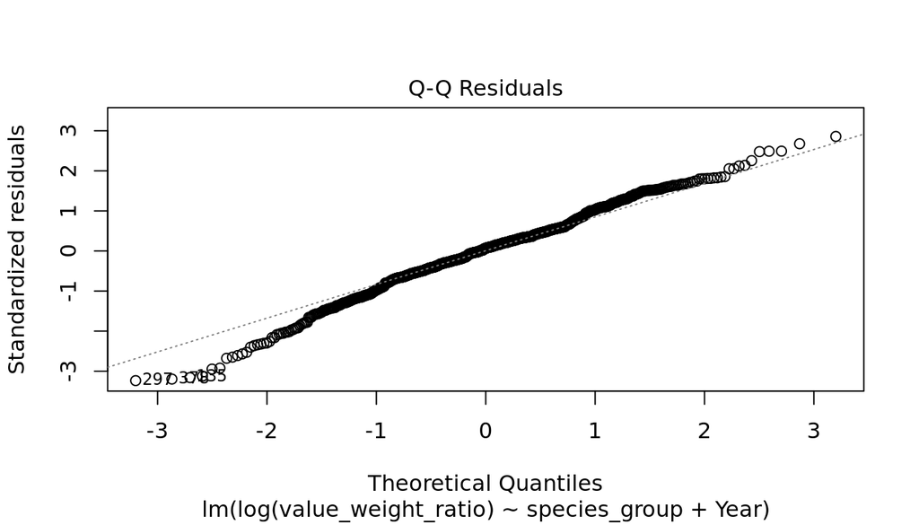

Model 1. Multiple Linear Regression of Logged Value to Weight Ratio of Commercial Landings in North Carolina by Species, 2014-2022

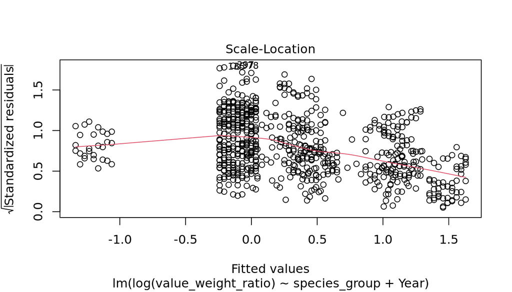

Model 1. Multiple Linear Regression of Logged Value to Weight Ratio of Commercial Landings in North Carolina by Species, 2014-2022

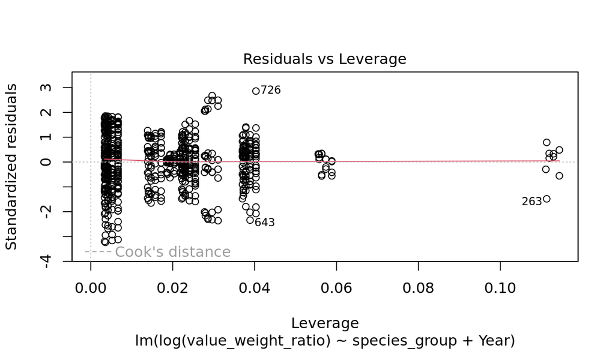

Model 1. Multiple Linear Regression of Logged Value to Weight Ratio of Commercial Landings in North Carolina by Species, 2014-2022

```
##
## Call:
## lm(formula = log(value_weight_ratio) ~ species_group + Year,
##     data = species_clean)
##
## Residuals:
##      Min       1Q   Median       3Q      Max
## -2.85749 -0.49237  0.05865  0.50527  2.47763
##
## Coefficients:
##                                      Estimate Std. Error t value Pr(>|t|)
## (Intercept)                        -6.444e-01  6.233e-01  -1.034 0.301512
## species_groupDrum & Croaker Family -4.933e-01  1.865e-01  -2.645 0.008350 **
## species_groupEels                  -2.761e-01  3.231e-01  -0.854 0.393138
## species_groupFlatfish               1.542e-01  2.468e-01   0.625 0.532155
## species_groupGroupers & Sea Basses  4.850e-01  1.786e-01   2.716 0.006773 **
## species_groupJacks & Pompanos      -7.108e-01  2.154e-01  -3.300 0.001014 **
## species_groupMackerels & Tunas     -5.829e-01  1.681e-01  -3.467 0.000557 ***
## species_groupMollusks               1.412e-01  1.865e-01   0.757 0.449351
## species_groupOther                 -6.520e-01  1.978e-01  -3.295 0.001031 **
## species_groupOther Finfish         -1.110e+00  1.415e-01  -7.842 1.61e-14 ***
## species_groupSharks & Rays         -2.205e+00  2.154e-01 -10.236  < 2e-16 ***
## species_groupSnappers & Porgies     8.942e-02  2.154e-01   0.415 0.678150
## species_groupUnclassified          -8.914e-01  2.154e-01  -4.139 3.91e-05 ***
## Year                                9.414e-05  3.475e-05   2.709 0.006901 **
## ---
## Signif. codes:  0 '***' 0.001 '**' 0.01 '*' 0.05 '.' 0.1 ' ' 1
##
## Residual standard error: 0.8848 on 715 degrees of freedom
## Multiple R-squared:  0.3344, Adjusted R-squared:  0.3223
## F-statistic: 27.63 on 13 and 715 DF,  p-value: < 2.2e-16
```

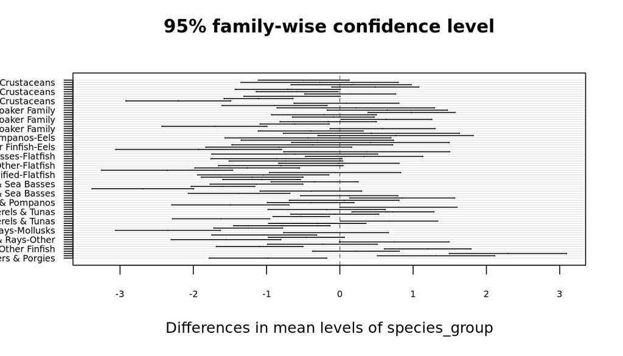

Figure 7. Tukey’s Post-Hoc test of ANOVA test for significant difference in value-to-weight ratio between species groups

**GLM Model 1**

```
##
## Call:
## glm(formula = FINALWEIGHT ~ FINALVALUE, family = Gamma(link = "log"),
##     data = species_clean)
##
## Coefficients:
##              Estimate Std. Error t value Pr(>|t|)
## (Intercept) 1.218e+01  6.959e-02   175.0   <2e-16 ***
## FINALVALUE  2.942e-07  1.911e-08    15.4   <2e-16 ***
## ---
## Signif. codes:  0 '***' 0.001 '**' 0.01 '*' 0.05 '.' 0.1 ' ' 1
##
## (Dispersion parameter for Gamma family taken to be 3.225651)
##
##     Null deviance: 2907  on 728  degrees of freedom
## Residual deviance: 1649  on 727  degrees of freedom
## AIC: 19488
##
## Number of Fisher Scoring iterations: 15
```

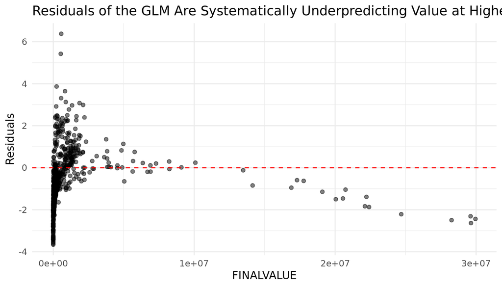

Figure 8. GLM Model #1, showing the residuals plot. Ideally, the residuals would be random, but this is not a necessary criteria

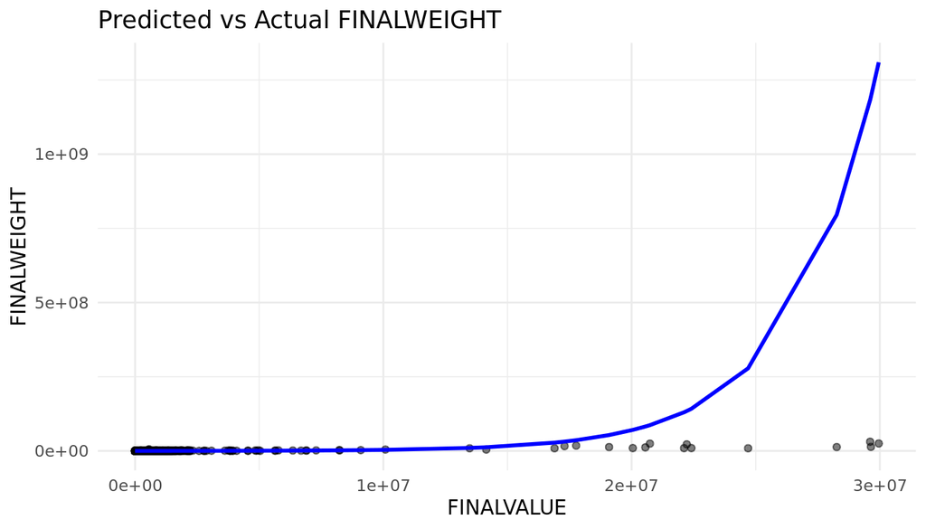

Figure 9. GLM Model #1, showing the actual verus predicted plot. It looks like this model is overpredicting

**GAM Model 1**

```
##
## Call: gam(formula = FINALWEIGHT ~ s(FINALVALUE), data = species_clean)
## Deviance Residuals:
##      Min       1Q   Median       3Q      Max
## -7000972  -113560   -84656   -27590 10667972
##
## (Dispersion Parameter for gaussian family taken to be 932537904768)
##
##     Null Deviance: 4.522872e+15 on 728 degrees of freedom
## Residual Deviance: 6.744155e+14 on 723.2043 degrees of freedom
## AIC: 22168.68
##
## Number of Local Scoring Iterations: NA
##
## Anova for Parametric Effects
##                  Df     Sum Sq    Mean Sq F value    Pr(>F)
## s(FINALVALUE)   1.0 3.6500e+15 3.6500e+15  3914.1 < 2.2e-16 ***
## Residuals     723.2 6.7442e+14 9.3254e+11
## ---
## Signif. codes:  0 '***' 0.001 '**' 0.01 '*' 0.05 '.' 0.1 ' ' 1
##
## Anova for Nonparametric Effects
##               Npar Df Npar F     Pr(F)
## (Intercept)
## s(FINALVALUE)     3.8 56.061 < 2.2e-16 ***
## ---
## Signif. codes:  0 '***' 0.001 '**' 0.01 '*' 0.05 '.' 0.1 ' ' 1
```

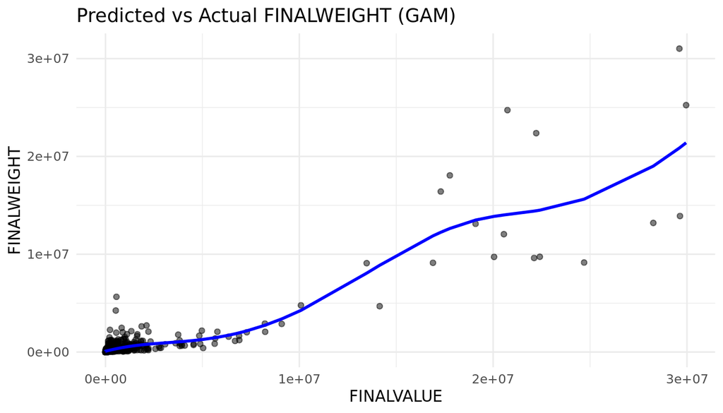

Figure 10. GAM Model #1

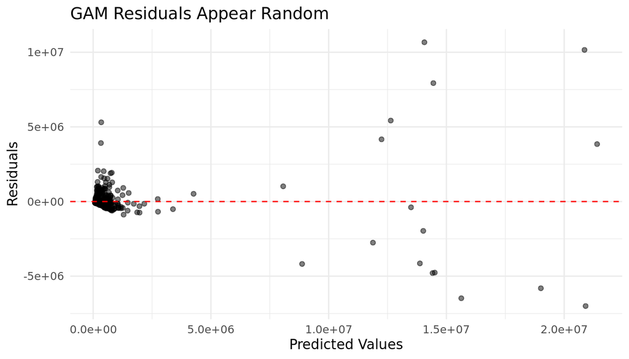

Figure 10. GAM Model #1

**GAM Model 2**

```
##
## Call: gam(formula = FINALWEIGHT ~ s(FINALVALUE) + species_group, data = species_clean)
## Deviance Residuals:
##      Min       1Q   Median       3Q      Max
## -7000998  -114728   -57562    47595 10668356
##
## (Dispersion Parameter for gaussian family taken to be 9.16408e+11)
##
##     Null Deviance: 4.522872e+15 on 728 degrees of freedom
## Residual Deviance: 6.517533e+14 on 711.2043 degrees of freedom
## AIC: 22167.76
##
## Number of Local Scoring Iterations: NA
##
## Anova for Parametric Effects
##                  Df     Sum Sq    Mean Sq F value  Pr(>F)
## s(FINALVALUE)   1.0 3.6500e+15 3.6500e+15  3983.0 < 2e-16 ***
## species_group  12.0 2.4193e+13 2.0161e+12     2.2 0.01038 *
## Residuals     711.2 6.5175e+14 9.1641e+11
## ---
## Signif. codes:  0 '***' 0.001 '**' 0.01 '*' 0.05 '.' 0.1 ' ' 1
##
## Anova for Nonparametric Effects
##               Npar Df Npar F     Pr(F)
## (Intercept)
## s(FINALVALUE)     3.8 35.904 < 2.2e-16 ***
## species_group
## ---
## Signif. codes:  0 '***' 0.001 '**' 0.01 '*' 0.05 '.' 0.1 ' ' 1
```

|  | df | AIC |
| --- | --- | --- |
| species_glm | 3 | 19487.60 |
| species_gam | 3 | 22168.68 |
| species_gam2 | 15 | 22167.76 |

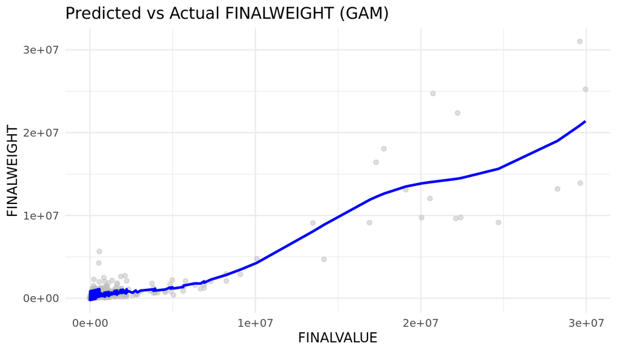

Figure 11. GAM Model #2, showing the actual versus predicted plot

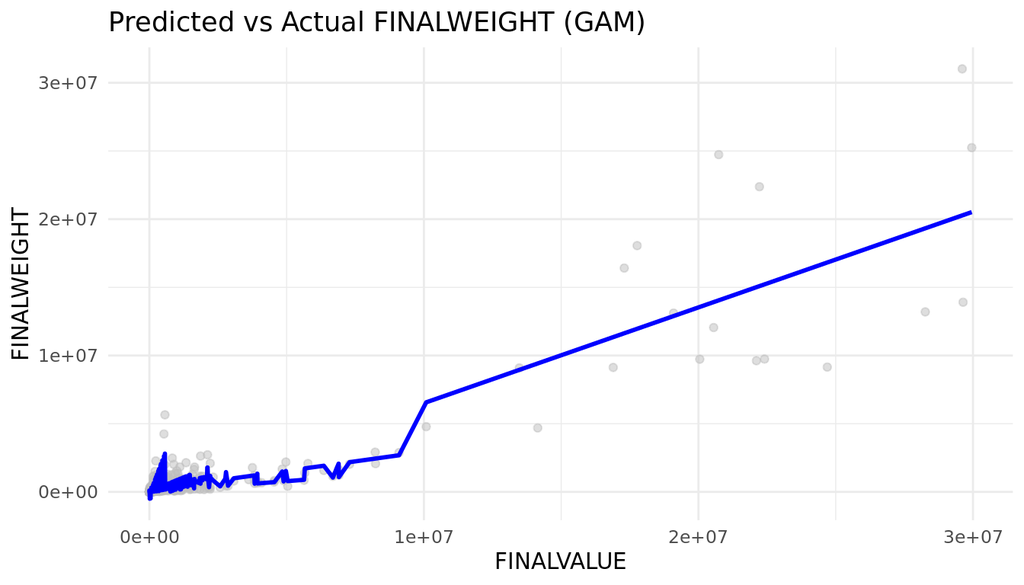

# 5 Summary and Conclusions

Answering our primary research question, based on the exhaustive analyses performed in this project, we conclude that there are significant differences in the value-to-weight ratio from commercial landings in North Carolina between 2014-2022. Furthermore, we conclude that – despite the issues with the models – there is a difference in the relationship between species groups and between counties. We also found that there are significant differences in the value-to-weight ratio across years and species groups and these variables are significant predictors of the value-to-weight ratio. These conclusions are confirmed by our exploratory visual analysis of the data where crustaceans have a much higher overall value than other species groups. Differences in value-to-weight ratio among species groups is more subtle, though from our multiple linear model we can conclude that groupers & sea basses have a significantly higher value-to-weight ratio than crustaceans and many groups including drums & croakers, jacks & pompanos, mackerels & tuna, sharks & rays, etc. had significantly lower values. Though we did not explore differences by county in depth, Craven County, NC saw the highest value-to-weight ratio in 2022.

From this analysis we can gain more of an understanding about commercial fishing in coastal North Carolina. Crustaceans make up a large part of both the weight of commercial landings and the value they bring in. This may be attributed primarily to shrimp and blue crab fishing - which consistently had the highest value and weight across our study period of 2014 - 2022. Shrimp fishing is particularly damaging to the environment because they are caught by trawling which involves dragging fishing nets across the sea floor, damaging benthic habitats. For fisheries managers in North Carolina, this may mean balancing the economic value these species bring in with environmental impacts while ensuring they are harvested at sustainable levels.

# 6 Next Steps

Future studies could analyze commercial landings by county in more depth to see if there are differences in profits by species groups in each county and whether some counties may bring in more commercial landings than others. One major piece that is not addressed in depth by the scope of this study is the temporal aspect of commercial fishing. Looking at how much commercial landings have changed over time and specifically across species groups could give information about environmental changes in species availability and demands of the seafood industry. Comparison of catch with changes in fisheries management and policy could be a beneficial way to ascertain whether management plans are effective. Beyond the scope of this study, looking at the impacts of fishing gear like trawling on coastal North Carolina habitats could be interesting to see and may have important implications for fisheries management.

# 7 References

*(1) Trip Ticket Program | NC DEQ. (n.d.). Retrieved April 20, 2025, from https://www.deq.nc.gov/about/divisions/marine-fisheries/science-and-statistics/trip-ticket-program*